# Gov 50 Final Project

Arjun Akwei

12/11/2022

## Introduction

For this project I explored how determining whether membership in a liberal international organization such as the EU has caused new member countries to develop economically in a significant way. Between 1990 and 2005 several former Soviet sphere countries were making the decision of whether or not to join the EU, and many EU members and allies listed greater economic development as a key selling point of joining. I was curious to assess whether such an impact was really seen.

My project curated a sample of countries from the “Eastern Bloc” that joined the EU in the same year, and mapped years spent in EU against their annual scores on the UN’s Human Development Index. I then conduct a difference in difference analysis using a sample of countries from that bloc that chose not to join the EU as a control group to determine the economic treatment effect of EU membership.

**Sample of Eastern Bloc countries now in EU**  
- Poland 2004  
- Czech Republic 2004  
- Estonia 2004  
- Hungary 2004  
- Slovakia 2004  
**Sample of Eastern bloc countries NOT in EU**  
- Albania  
- Moldova  
- Ukraine  
- Belarus  
- Georgia

## Hypothesis and discussion of data

I hypothesized, facilitated integration into the global economy, as well as direct support from the EU itself, would cause member organizations to develop at rates far faster than they would have without joining. The explanatory variable in this case is time spent as a member of the EU, something measured in years since being granted membership in 2004. A separate set of countries from the same region that did NOT join the EU will be established as a comparative to isolate the difference. The outcome variable I will be tracking is economic development, as quantified by the UN’s Human Development Index. This is an annual evaluation of how developed a given country is. It incorporates the following factors: life expectancy at birth, mean of years of schooling for adults aged 25 years and more, expected years of schooling for children of school entering age, and gross national income per capita. The data is published for each country as far back as 1990, but I had to combine these country data-sets into one in order to perform my analysis.

Rather than simply assessing growth since joining, I chose to conduct a difference in differences analysis to isolate the impact of EU membership from the impact of year on year growth. I expected that over time most of these countries will have trended towards becoming more developed, but a difference-in-differences analysis will reveal whether the explanatory had some additional effect. If the difference-in-differences analysis indicates a higher rate of development in member countries vs non-member countries, this will suggest that time spent within the EU is positively related to development, proving the hypothesis correct. No significant difference or a negative relationship would disprove the hypothesis.

## Graph 1: Country HDI 1990-2021 (categorized by EU membership)

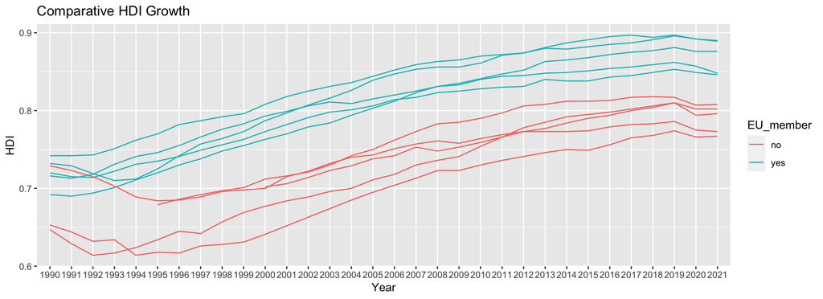

## Graph 2: Aggregated HDI scores over time (EU vs Non-EU)

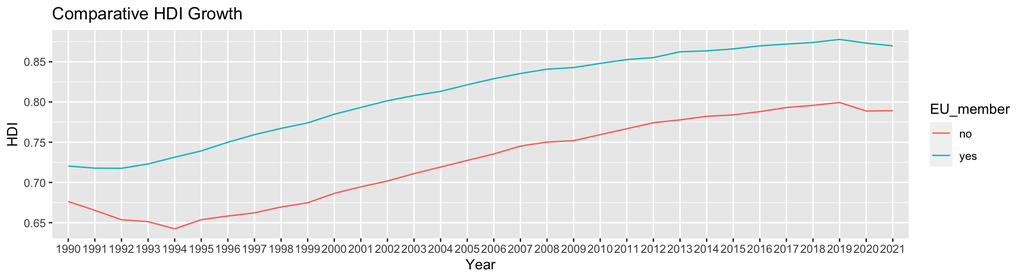

## Regression: Difference in Differences

```
##
## Call:
## lm(formula = mean_HDI ~ EU + time + did, data = comparative_analysis)
##
## Residuals:
##       Min        1Q    Median        3Q       Max
## -0.049033 -0.017899  0.002305  0.018567  0.051743
##
## Coefficients:
##              Estimate Std. Error t value Pr(>|t|)
## (Intercept) 0.6715214  0.0065611 102.349  < 2e-16 ***
## EU          0.0847357  0.0092788   9.132 5.92e-13 ***
## time        0.0967119  0.0087481  11.055 4.18e-16 ***
## did         0.0007643  0.0123717   0.062    0.951
## ---
## Signif. codes:  0 '***' 0.001 '**' 0.01 '*' 0.05 '.' 0.1 ' ' 1
##
## Residual standard error: 0.02455 on 60 degrees of freedom
## Multiple R-squared:  0.8797, Adjusted R-squared:  0.8737
## F-statistic: 146.3 on 3 and 60 DF,  p-value: < 2.2e-16
```

## Results and Analysis

Based on the difference in differences analysis I ran, the coefficients yielded for did were 0.0007643 and 0.0123717 for the estimate and standard error respectively. This estimator suggests that EU members year-on-year saw an additional 0.076% growth in HDI compared to the control group of non-EU countries. This would suggest that EU membership does have a positive, though slight, impact on HDI growth beyond what would be seen in normal year-on-year progress. However, the standard error for the did estimator is 1.2%, and the p value is 0.951. Not only is the standard error visibly high, the p value is well above a 0.05 alpha level required for confidence in these results. This would mean that we would not be able to reject a null hypothesis that there was no significant difference in HDI growth between the treatment and control groups. Relatedly, this impact is significantly smaller than the time coefficient, suggesting that year-over-year progress regardless of EU membership was the bigger driver of HDI growth.

## Conclusion

This study was limited in that the countries I chose as the control group were imperfect foils to the treatment group. Though their HDIs were closer pre 1991, there was already a difference in HDI to start that may have impacted my findings. Perhaps if compared to a more similar control, different results would have been found. Thus, one meaningful improvement to make would be doing a more sophisticated selection of countries beyond my sorting of Soviet Eastern Bloc countries.